# Challenge-5

Jing Ying

2023-09-14

```r
knitr::opts_chunk$set(echo = TRUE)
```

## Questions

#### Question-1: Local Variable Shadowing

Create an R function that defines a global variable called `x` with a value of 5. Inside the function, declare a local variable also named `x` with a value of 10. Print the value of `x` both inside and outside the function to demonstrate shadowing.

**Solutions:**

```r
# Enter code here

shadowing_example <- function() {
  x <- 10

  cat("Value of x inside the function:", x, "\n")
}

x <- 5

cat("Value of x outside the function:", x, "\n")
```

```
## Value of x outside the function: 5
```

```r
shadowing_example()
```

```
## Value of x inside the function: 10
```

```r
cat("Value of x outside the function after shadowing:", x, "\n")
```

```
## Value of x outside the function after shadowing: 5
```

#### Question-2: Modify Global Variable

Create an R function that takes an argument and adds it to a global variable called `total`. Call the function multiple times with different arguments to accumulate the values in `total`.

**Solutions:**

```r
# Enter code here

total <- 1

accumulate_total <- function(value) {
  total <<- total + value}
accumulate_total(5)
accumulate_total(10)
accumulate_total(3)

print(total)
```

```
## [1] 19
```

#### Question-3: Global and Local Interaction

Write an R program that includes a global variable `total` with an initial value of 100. Create a function that takes an argument, adds it to `total`, and returns the updated `total`. Demonstrate how this function interacts with the global variable.

**Solutions:**

```r
# Enter code here

total <- 100

add_to_total <- function(num) {
  total <<- total + num
  return(total)
}

cat("Initial value of total:", total, "\n")
```

```
## Initial value of total: 100
```

```r
result1 <- add_to_total(50)
cat("After adding 50, total becomes:", result1, "\n")
```

```
## After adding 50, total becomes: 150
```

```r
result2 <- add_to_total(25)
cat("After adding 25, total becomes:", result2, "\n")
```

```
## After adding 25, total becomes: 175
```

```r
cat("Final value of total:", total, "\n")
```

```
## Final value of total: 175
```

#### Question-4: Nested Functions

Define a function `outer_function` that declares a local variable `x` with a value of 5. Inside `outer_function`, define another function `inner_function` that prints the value of `x`. Call both functions to show how the inner function accesses the variable from the outer function’s scope.

**Solutions:**

```r
# Enter code here

outer_function <- function() {
  x <- 5
  inner_function <- function() {
    print(x)
  }
  inner_function()
}

outer_function()
```

```
## [1] 5
```

#### Question-5: Meme Generator Function

Create a function that takes a text input and generates a humorous meme with the text overlaid on an image of your choice. You can use the `magick` package for image manipulation. You can find more details about the commands offered by the package, with some examples of annotating images here: https://cran.r-project.org/web/packages/magick/vignettes/intro.html

**Solutions:**

```r
# Enter code here

install.packages("magick",repos = "http://cran.us.r-project.org")
library(magick)
str(magick::magick_config())
```

[output not shown]

```r
magick::magick_config()
```

[output not shown]

[output cut: 16 more lines]

[output not shown]

```r
# Enter code here

generate_meme <- function(text, image_path) {
  image <- image_read(image_path)
  image <- image_scale(image, "500")
  meme <- image_annotate(image, text, gravity = "center", color = "white", size = 20, boxcolor = "black")
  image_browse(meme)
  output_path <- paste0("meme_", format(Sys.time(), "%Y%m%d%H%M%S"), ".png")
  image_write(meme, output_path)
  return(output_path)
}

text_input <- "when the deck cai fan becomes a scam"
image_path <- "C:/Users/yeojy/Pictures/jiakcao.jpg"
gimmemycaipngback <- generate_meme(text_input, image_path)

print(gimmemycaipngback)
```

```
## [1] "meme_20230914142322.png"
```

[figure not shown]

```r
knitr::include_graphics("C:/Users/yeojy/Documents/Y2S1/NM2207/Week 5/meme_20230911194057.png")
```

#### Question-6: Text Analysis Game

Develop a text analysis game in which the user inputs a sentence, and the R function provides statistics like the number of words, characters, and average word length. Reward the user with a “communication skill level” based on their input.

**Solutions:**

```r
# Enter code here

text_analysis_game <- function() {
  cat("Enter a sentence: ")
  sentence <- readLines(n = 1)

  if (nchar(trimws(sentence)) == 0) {
    cat("Error: Empty sentence. Please enter a valid sentence.\n")
    return()
  }

  sentence <- sentence[1]

  words <- strsplit(sentence, "\\s+")
  num_words <- length(words[[1]])

  num_chars <- nchar(sentence)

  word_lengths <- sapply(words[[1]], nchar)
  avg_word_length <- mean(word_lengths)

  cat("\nText Statistics:\n")
  cat("Number of words:", num_words, "\n")
  cat("Number of characters:", num_chars, "\n")
  cat("Average word length:", avg_word_length, "\n")

  skill_level <- ifelse(avg_word_length < 4, "NOOB",
                        ifelse(avg_word_length < 6, "UR OK", "PRETENTIOUS"))

  cat("\nYour Communication Skill Level:", skill_level, "\n")
}

text_analysis_game()
```

```
## Enter a sentence: Error: Empty sentence. Please enter a valid sentence.
```

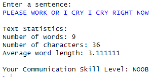

```r
knitr::include_graphics("C:/Users/yeojy/Documents/Y2S1/NM2207/Week 5/YAYYAYYAYYYYAYYYAYYYYYY.png")
```